# Individual Differences

Dan Mirman

24 January 2019

## Individual differences

Individual differences provide an additional level of analysis for understanding phenomena

- At a group level, a treatment works better than a placebo, but why does it work better for some people than for others?
- People solve easy problems faster than hard problems, but why are some people a lot faster on the easy problems and other people only a little faster?
- t-test and ANOVA methods treat individual differences as noise
- Multilevel regression provides two ways to quantify and analyze individual differences

## “External” individual differences can be added as fixed effects

Example: National Youth Survey longitudinal data on tolerance for deviant behavior, exposure to deviant behavior, and gender. Subset of 16 subjects printed in Willett (1997, Table 11.1). (`DeviantBehavior`: http://dmirman.github.io/ET2019/DeviantBehavior.rda)

`Tolerance` was measured by asking whether it is wrong for someone their age to: cheat on tests, purposely destroy property of others, use marijuana, steal something worth less than $5, hit or threaten someone without reason, use alcohol, break into a building or vehicle to steal, sell hard drugs, or steal something worth more than $50.

```
##      SubjID      Gender      Exposure          Age       Tolerance
##  S0009  : 5   Female:45   Min.   :0.810   Min.   :11   Min.   :1.00
##  S0045  : 5   Male  :35   1st Qu.:0.922   1st Qu.:12   1st Qu.:1.22
##  S0268  : 5               Median :1.145   Median :13   Median :1.50
##  S0314  : 5               Mean   :1.191   Mean   :13   Mean   :1.62
##  S0442  : 5               3rd Qu.:1.395   3rd Qu.:14   3rd Qu.:1.99
##  S0514  : 5               Max.   :1.990   Max.   :15   Max.   :3.46
##  (Other):50
```

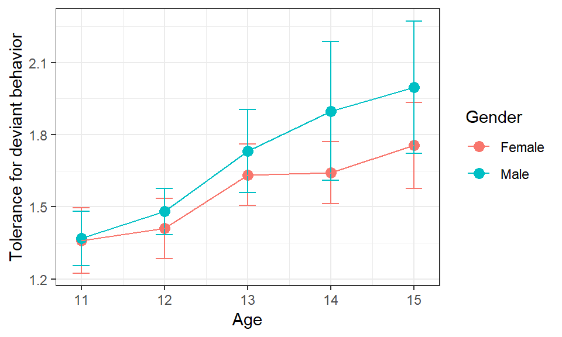

## Does tolerance increase with age and is it modulated by gender?

```r
m.base <- lmer(Tolerance ~ Age*Gender + (Age | SubjID),
                 contrasts=list(Gender="contr.sum"), data=DeviantBehavior)
get_pvalues(m.base)
```

```
##             Estimate Std..Error t.value p.normal p.normal.star
## (Intercept) -0.12563    0.52513 -0.2392 0.810928
## Age          0.13488    0.04409  3.0593 0.002218            **
## Gender1      0.35552    0.52513  0.6770 0.498406
## Age:Gender1 -0.03255    0.04409 -0.7382 0.460371
```

Significant increase with age, no significant effects of gender

## Is this modulated by exposure to deviant behavior?

`Exposure` scale is not clear and other effects would be estimated at `Exposure=0`, which is not an attested value.

If we center `Exposure`, its effects and the effects of other predictors will be easier to interpret.

```r
# center Exposure, but do not re-scale it
DeviantBehavior$Exposure.center <- scale(DeviantBehavior$Exposure, scale=FALSE)
```

## Is this modulated by exposure to deviant behavior?

```r
# full model
m.exp1 <- lmer(Tolerance ~ Age*Gender*Exposure.center + (Age | SubjID),
               data=DeviantBehavior, contrasts=list(Gender="contr.sum"))
get_pvalues(m.exp1)
```

```
##                             Estimate Std..Error t.value  p.normal p.normal.star
## (Intercept)                 -0.38880    0.43008  -0.904 3.660e-01
## Age                          0.15603    0.03492   4.468 7.881e-06           ***
## Gender1                      0.65192    0.43008   1.516 1.296e-01
## Exposure.center             -4.22668    1.47541  -2.865 4.173e-03            **
## Age:Gender1                 -0.05921    0.03492  -1.696 8.993e-02             .
## Age:Exposure.center          0.38532    0.11979   3.217 1.297e-03            **
## Gender1:Exposure.center      3.62705    1.47541   2.458 1.396e-02             *
## Age:Gender1:Exposure.center -0.28576    0.11979  -2.385 1.706e-02             *
```

- Significant main effects: Age and Exposure
- Significant interactions:
  - Age-by-Exposure
  - Gender-by-Exposure
  - Age-by-Gender-by-Exposure

## How to plot the three-way interaction?

The three-way Age-by-Gender-by-Exposure interaction is a relationship among four variables (Tolerance for deviant behavior, Exposure to deviant behavior, Age, and Gender), three of which are continuous variables. *This is hard to visualize.*

To make it easier to visualize, can split the `Exposure` into levels

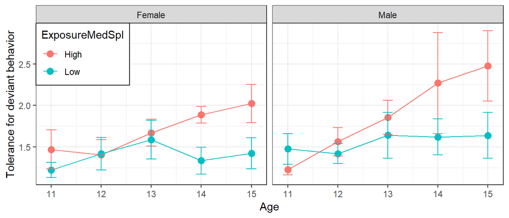

```r
# a simple median split
DeviantBehavior$ExposureMedSpl <- ifelse(
  DeviantBehavior$Exposure >= median(DeviantBehavior$Exposure), "High", "Low")
# plot the interaction
ggplot(DeviantBehavior, aes(Age, Tolerance, color=ExposureMedSpl)) + facet_wrap(~ Gender) +
  stat_summary(fun.y=mean, geom="point", size=3) + stat_summary(fun.y=mean, geom="line") +
  stat_summary(fun.data=mean_se, geom="errorbar", width=0.2) +
  labs(x="Age", y="Tolerance for deviant behavior") +
  theme_bw() + legend_positioning(c(0,1))
```

Adolescents with higher Exposure to deviant behavior tend to have increased Tolerance for deviant behavior as they get older, and this is more true for males than females.

## How to plot the three-way interaction?

To make it easier to visualize, can split the `Exposure` into levels: tertile split

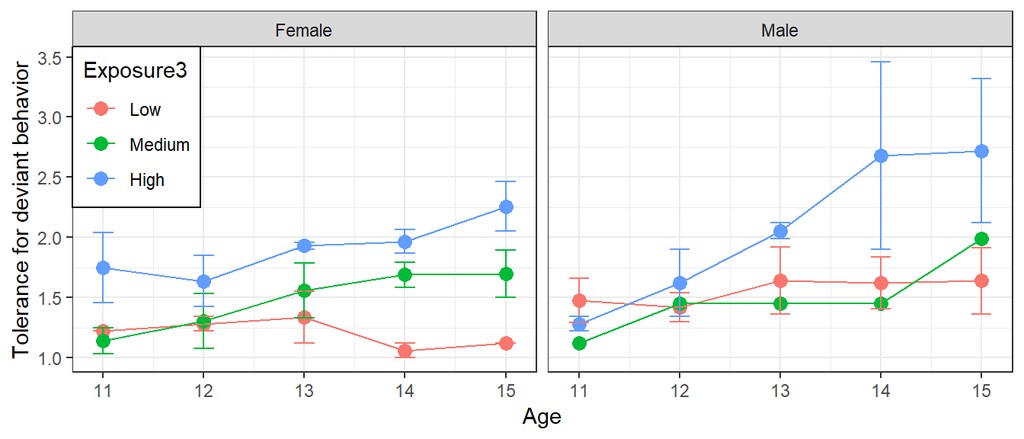

```r
# define break points
b <- quantile(DeviantBehavior$Exposure, probs=seq(0, 1, by=1/3))
# split continuous predictor and provide level labels
DeviantBehavior$Exposure3 <- cut(DeviantBehavior$Exposure,
                                 breaks=b, include.lowest=T,
                                 labels=c("Low", "Medium", "High"))
# make the plot
ggplot(DeviantBehavior, aes(Age, Tolerance, color=Exposure3)) + facet_wrap(~ Gender) +
  stat_summary(fun.y=mean, geom="point", size=3) + stat_summary(fun.y=mean, geom="line") +
  stat_summary(fun.data=mean_se, geom="errorbar", width=0.2) +
  labs(x="Age", y="Tolerance for deviant behavior") +
  theme_bw() + legend_positioning(c(0,1))
```

## “Internal” individual differences

- No “external” measure that can be entered as a fixed effect
- Individual differences needed for a different analysis (e.g., VLSM)

For such situations, random effects provide a way to quantify individual effect sizes in the context of a model of overall group performance.

A simple example:

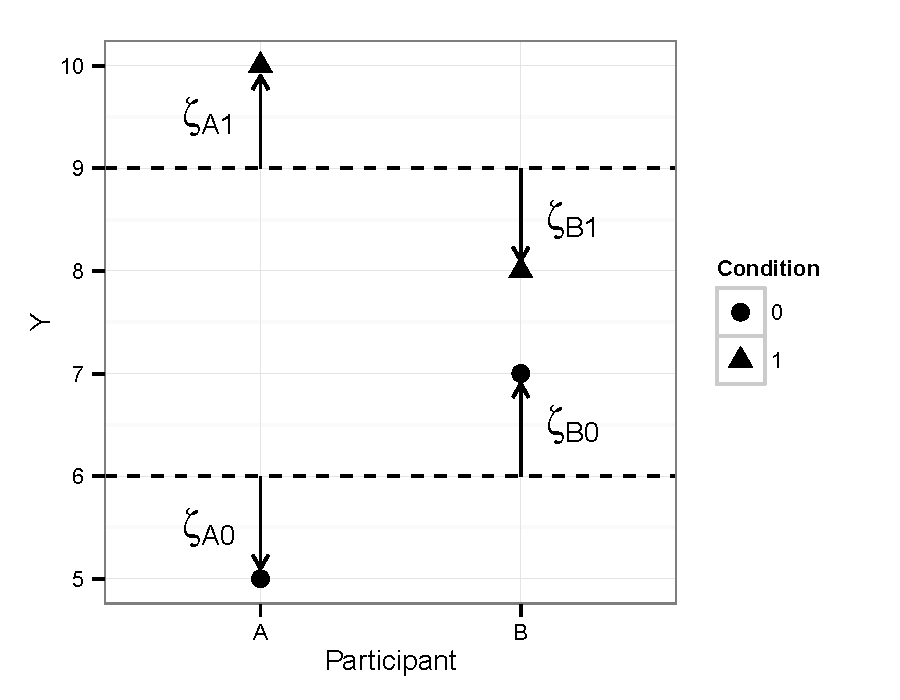

Participant A: $\zeta_{A1} - \zeta_{A0} = 1 - (-1) = 2$

Participant B: $\zeta_{B1} - \zeta_{B0} = (-1) - 1 = -2$

## “Internal” individual differences: Example

Data: Function and Thematic competition for 17 LH stroke patients (`FunctThemePts`)

```
##       subj         Condition           Object          Time
##  206    : 486   Function:4113   Target    :2733   Min.   :-1000
##  281    : 486   Thematic:4086   Competitor:2733   1st Qu.:    0
##  419    : 486                   Unrelated :2733   Median : 1000
##  1088   : 486                                     Mean   : 1000
##  1238   : 486                                     3rd Qu.: 2000
##  1392   : 486                                     Max.   : 3000
##  (Other):5283
##     timeBin      meanFix           sumFix            N
##  Min.   : 0   Min.   :0.0000   Min.   : 0.00   Min.   :12.0
##  1st Qu.:20   1st Qu.:0.0312   1st Qu.: 1.00   1st Qu.:15.0
##  Median :40   Median :0.1250   Median : 2.00   Median :16.0
##  Mean   :40   Mean   :0.1777   Mean   : 3.26   Mean   :15.4
##  3rd Qu.:60   3rd Qu.:0.2500   3rd Qu.: 5.00   3rd Qu.:16.0
##  Max.   :80   Max.   :1.0000   Max.   :16.00   Max.   :16.0
##
```

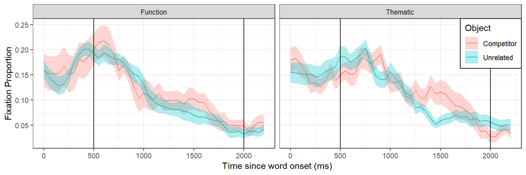

Question: is there a correlation between Function and Thematic competition across patients?

## “Internal” individual differences: Example - fit the models

```r
#prep data for GCA
FunctThemePts.gca <- code_poly(subset(FunctThemePts, Time >= 500 & Time <= 2000 &
                                        Object != "Target"),
                               predictor="Time", poly.order=4, draw.poly = FALSE)

# function competition: full model
m.funct <- lmer(meanFix ~ (poly1+poly2+poly3+poly4)*Object +
                  (poly1+poly2+poly3+poly4 | subj) + (poly1+poly2 | subj:Object),
                data=subset(FunctThemePts.gca, Condition == "Function"), REML=F)
# thematic competition: full model
m.theme <- lmer(meanFix ~ (poly1+poly2+poly3+poly4)*Object +
                  (poly1+poly2+poly3+poly4 | subj) + (poly1+poly2 | subj:Object),
                data=subset(FunctThemePts.gca, Condition == "Thematic"), REML=F)
```

## “Internal” individual differences: Example - examine random effects

```r
str(ranef(m.funct), vec.len=2)
```

```
## List of 2
##  $ subj:Object:'data.frame': 34 obs. of  3 variables:
##   ..$ (Intercept): num [1:34] -0.0327 0.0254 ...
##   ..$ poly1      : num [1:34] 0.0339 0.0726 ...
##   ..$ poly2      : num [1:34] -0.1538 0.0143 ...
##  $ subj       :'data.frame': 17 obs. of  5 variables:
##   ..$ (Intercept): num [1:17] 0.025 -0.0134 ...
##   ..$ poly1      : num [1:17] 0.0924 -0.0454 ...
##   ..$ poly2      : num [1:17] -0.1915 0.0375 ...
##   ..$ poly3      : num [1:17] 0.1124 -0.0677 ...
##   ..$ poly4      : num [1:17] 0.0386 0.0474 ...
##  - attr(*, "class")= chr "ranef.mer"
```

```r
head(ranef(m.funct)$"subj:Object")
```

```
##                (Intercept)    poly1     poly2
## 206:Competitor  -0.0327460  0.03386 -0.153809
## 206:Unrelated    0.0253878  0.07261  0.014314
## 281:Competitor   0.0066498 -0.04395 -0.059606
## 281:Unrelated   -0.0200312 -0.05530  0.115819
## 419:Competitor  -0.0006385  0.24667 -0.001246
## 419:Unrelated   -0.0092935 -0.15294  0.056835
```

We can use these to calculate individual effect sizes, just like in the simple demo example.

## “Internal” individual differences: Example - extract random effects

Use `gazer::get_ranef()`, which is a helper function for extracting random effects

```r
re.funct <- get_ranef(m.funct, "subj:Object")
head(re.funct)
```

```
##                 Intercept    poly1     poly2 subj     Object
## 206:Competitor -0.0327460  0.03386 -0.153809  206 Competitor
## 206:Unrelated   0.0253878  0.07261  0.014314  206  Unrelated
## 281:Competitor  0.0066498 -0.04395 -0.059606  281 Competitor
## 281:Unrelated  -0.0200312 -0.05530  0.115819  281  Unrelated
## 419:Competitor -0.0006385  0.24667 -0.001246  419 Competitor
## 419:Unrelated  -0.0092935 -0.15294  0.056835  419  Unrelated
```

## “Internal” individual differences: Example - compute individual effect sizes from random effects

Compute individual effect size as random effects difference between the two Conditions for each Subject for Intercept and Linear time term

```r
ES.funct <- re.funct %>% group_by(subj) %>%
  summarize(Function_Intercept = Intercept[Object=="Competitor"] - Intercept[Object=="Unrelated"],
            Function_Linear = poly1[Object=="Competitor"] - poly1[Object=="Unrelated"])
head(ES.funct)
```

```
## # A tibble: 6 x 3
##   subj  Function_Intercept Function_Linear
##   <chr>              <dbl>           <dbl>
## 1 1088            -0.00328          -0.156
## 2 1238            -0.0133           -0.140
## 3 1392            -0.00320           0.191
## 4 1626             0.0281            0.278
## 5 1687             0.0565           -0.251
## 6 1846            -0.0788            0.399
```

## “Internal” individual differences: Example - compute individual effect sizes from random effects

Repeat those steps for Thematic condition

```r
re.theme <- get_ranef(m.theme, "subj:Object")
ES.theme <- re.theme %>% group_by(subj) %>%
  summarize(Thematic_Intercept = Intercept[Object=="Competitor"] - Intercept[Object=="Unrelated"],
            Thematic_Linear = poly1[Object=="Competitor"] - poly1[Object=="Unrelated"])
head(ES.theme)
```

```
## # A tibble: 6 x 3
##   subj  Thematic_Intercept Thematic_Linear
##   <chr>              <dbl>           <dbl>
## 1 1088            -0.0846          -0.0619
## 2 1238            -0.0221          -0.0156
## 3 1392             0.0615          -0.353
## 4 1626             0.0246          -0.469
## 5 1687            -0.0226          -0.0485
## 6 1846             0.00176          0.155
```

## “Internal” individual differences: Example - analyze association between effect sizes

```r
# combine condition effect sizes into one data frame
ES <- merge(ES.funct, ES.theme)
summary(ES)
```

```
##      subj           Function_Intercept Function_Linear
##  Length:17          Min.   :-0.0788    Min.   :-0.3659
##  Class :character   1st Qu.:-0.0508    1st Qu.:-0.2511
##  Mode  :character   Median :-0.0027    Median :-0.0388
##                     Mean   : 0.0000    Mean   : 0.0000
##                     3rd Qu.: 0.0267    3rd Qu.: 0.1912
##                     Max.   : 0.1076    Max.   : 0.4237
##  Thematic_Intercept Thematic_Linear
##  Min.   :-0.08556   Min.   :-0.4691
##  1st Qu.:-0.02205   1st Qu.:-0.1529
##  Median :-0.00187   Median :-0.0485
##  Mean   : 0.00000   Mean   : 0.0000
##  3rd Qu.: 0.02460   3rd Qu.: 0.1554
##  Max.   : 0.07799   Max.   : 0.6714
```

```r
# compute correlations between effect sizes
cor.test(ES$Function_Intercept, ES$Thematic_Intercept)
```

```
##
##  Pearson's product-moment correlation
##
## data:  ES$Function_Intercept and ES$Thematic_Intercept
## t = -2.4, df = 15, p-value = 0.03
## alternative hypothesis: true correlation is not equal to 0
## 95 percent confidence interval:
##  -0.8007 -0.0530
## sample estimates:
##     cor
## -0.5204
```

```r
cor.test(ES$Function_Linear, ES$Thematic_Linear)
```

```
##
##  Pearson's product-moment correlation
##
## data:  ES$Function_Linear and ES$Thematic_Linear
## t = -3.4, df = 15, p-value = 0.004
## alternative hypothesis: true correlation is not equal to 0
## 95 percent confidence interval:
##  -0.8637 -0.2545
## sample estimates:
##    cor
## -0.655
```

## “Internal” individual differences: Example - scatterplot

A two-panel scatterplot that shows correlations between Function and Thematic competition effect sizes on each of the terms (Intercept, Linear).

```r
# need to re-arrange the data
ES.p <- gather(ES, key = "key", value = "value", 2:5) %>% # "gather" into long form
  separate(key, c("Condition", "Term"), sep = "_") %>% # separate the labels into two columns
  spread(key = Condition, value = value) # "spread" so conditions are in separate columns
summary(ES.p)
```

```
##      subj               Term              Function          Thematic
##  Length:34          Length:34          Min.   :-0.3659   Min.   :-0.4691
##  Class :character   Class :character   1st Qu.:-0.0736   1st Qu.:-0.0647
##  Mode  :character   Mode  :character   Median :-0.0029   Median :-0.0077
##                                        Mean   : 0.0000   Mean   : 0.0000
##                                        3rd Qu.: 0.0436   3rd Qu.: 0.0294
##                                        Max.   : 0.4237   Max.   : 0.6714
```

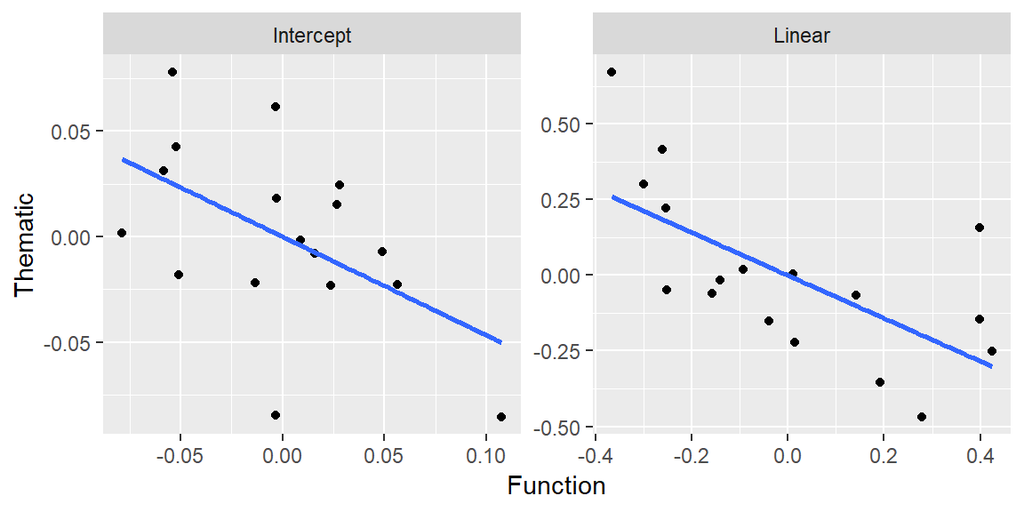

```r
# now can make the plot
ggplot(ES.p, aes(Function, Thematic)) +
  facet_wrap(~ Term, scales="free") + geom_point() +
  stat_smooth(method="lm", se=F) # add trendline
```

## “Internal” individual differences: Why bother?

Why bother with the model-fitting when you could just take the difference of the observed data to get effect sizes?

- That would *over-estimate* the individual differences
- Stein’s paradox (Efron & Morris, 1977): An individual’s mid-season batting average is *not* the best prediction of final batting average. Including MLB grand mean batting average and variability of batting averages improves the estimate.
- Why?
- Individual model assigns all of the individual effect size to that individual
- Group (multilevel) model estimates a mean group effect, individual differences from that mean, and noise.
- This allows the estimate of the individual effect size to be informed by (a) a model of the performance of the group of which this individual is a member and (b) the fact that some of the observed individual difference is just random noise.
- This “shrinks” the individual effect size estimate toward the group mean in proportion to the model’s cetainty about that mean and estimate of the noisiness of the data (aka *partial pooling*).

## “Internal” individual differences: Why bother? Partial poooling

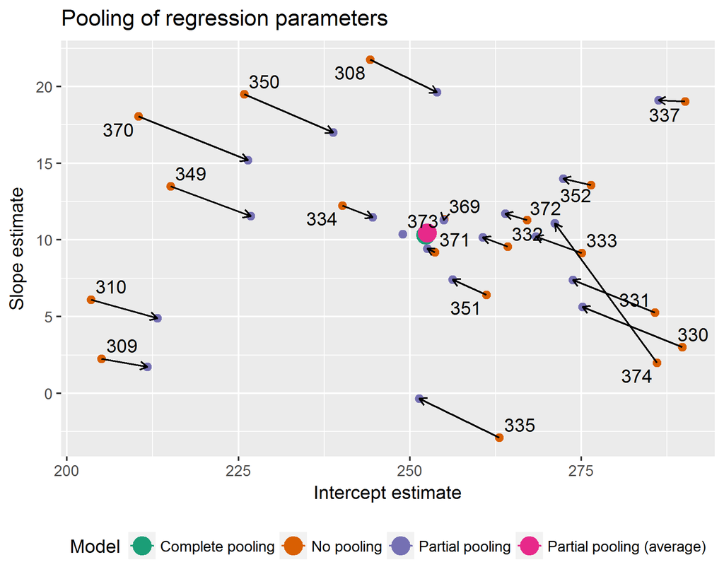

http://tjmahr.github.io/plotting-partial-pooling-in-mixed-effects-models/

## “Internal” individual differences: Why bother? Example

Individual participant `Function` competition effect sizes

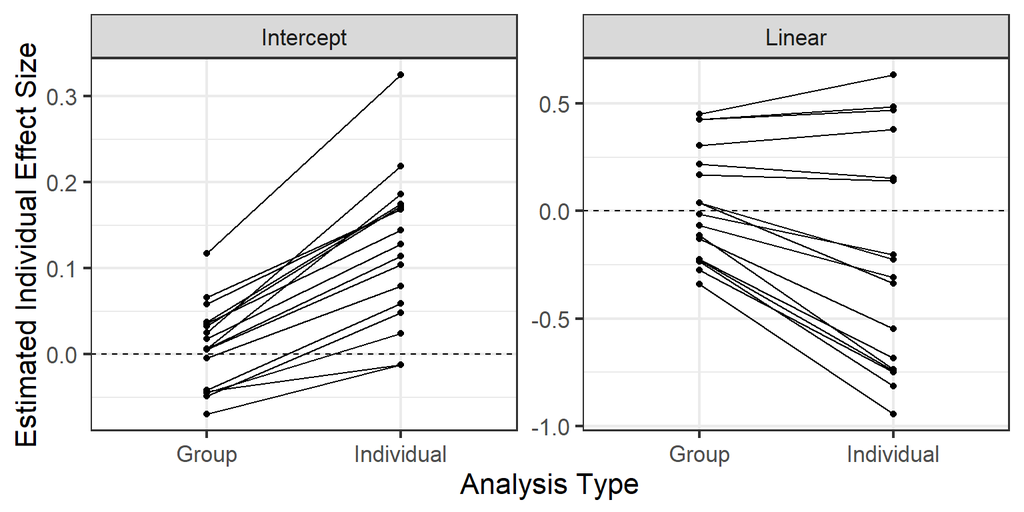

## Exercise 5

The `CohortRhyme` data set contains data from an eye-tracking experiment (Mirman et al., 2011) that investigated phonological competition between cohorts (e.g., penny - pencil) and rhymes (e.g., carrot - parrot).

Three groups of participants were tested: 5 Broca’s aphasics, 3 Wernicke’s aphasics, and 12 control participants.

```r
summary(CohortRhyme)
```

```
##      subjID          Group          Time         timeBin
##  101    :  80   Control :960   Min.   :  50   Min.   : 1.00
##  102    :  80   Broca   :400   1st Qu.: 525   1st Qu.: 5.75
##  103    :  80   Wernicke:240   Median :1000   Median :10.50
##  104    :  80                  Mean   :1000   Mean   :10.50
##  105    :  80                  3rd Qu.:1475   3rd Qu.:15.25
##  106    :  80                  Max.   :1950   Max.   :20.00
##  (Other):1120
##         Object        Type        FixProp
##  Competitor:800   Cohort:800   Min.   :0.0000
##  Unrelated :800   Rhyme :800   1st Qu.:0.0000
##  Target    :  0                Median :0.0417
##                                Mean   :0.0665
##                                3rd Qu.:0.1000
##                                Max.   :0.5833
##
```

- Make a multi-panel plot showing each kind of competition for each group
- Use fourth-order orthogonal polynomials to analyze (separately) the cohort and rhyme competition effects. Do the diagnosis groups differ in competition effect sizes?
- Use random effects to compute individual competition effect sizes (note: you’ll need to use a model without any group fixed effects to get random effects relative to the overall sample rather than the diagnosis sub-group).
- Test correlations between cohort and rhyme competition effects for patients and controls.
- Make a multi-panel scatterplot showing these correlations.